# variancePartition Exercise Response: ImmVar Dataset

Panjun Kim

2026-06-25

# 1. Overview of dataset and variancePartition

The `variancePartition` framework provides a practical way to estimate how much gene expression variation is attributable to measured biological and technical factors. Rather than focusing only on individual differential-expression contrasts, it fits a model for each gene and partitions the variation across terms such as cell type, donor identity, age, sex, batch, and residual variation.

The ImmVar data used here are public microarray expression data from CD4+ T cells and CD14+ monocytes purified from PBMCs collected from healthy individuals. This is not a disease case-control dataset, so I interpreted the analysis as a study of baseline immune-cell expression variation rather than disease-associated expression change.

I treat these estimates as a way to describe how much expression variation is linked to each factor, not as proof of causality. The results depend on the available metadata, the model formula, and the degree of confounding among variables. In this exercise I used `variancePartition` as a structured framework for asking which factors explain the dominant patterns of expression variation in the ImmVar data.

# 2. ImmVar analysis

I analyzed the two GEO series as Bioconductor `ExpressionSet` objects, matched them by shared Affymetrix probe identifiers, and combined them into one expression matrix. The GEO metadata states that the expression values were processed using an RMA workflow and exported on a 2^ scale, so I transformed the matrix using `log2(pmax(raw_value, 1))` before QC, PCA, and modeling.

| metric | value |
| --- | --- |
| Data source | GSE56033 CD4+ T cells; GSE56034 CD14+ monocytes |
| Platform | GPL6244 Affymetrix HuGene-1.0-ST microarray |
| Samples before model filtering | 984 |
| Samples used in model | 938 |
| Probes before filtering | 21,727 |
| Probes used in model | 21,727 |
| Expression transform | log2(pmax(raw_value, 1)) |

Table 1. Dataset and model input summary.

Before modeling, I used targeted QC checks to verify the inputs needed for the mixed model rather than to perform a comprehensive quality-control study. Sample and probe counts confirmed that the CD4 and CD14 matrices were merged as expected (499 CD4+ T cell samples, 485 CD14+ monocyte samples, 984 total samples, and 21,727 probes before filtering). Missing-covariate checks defined which samples could be used in the model (46 samples were excluded because of missing model covariates, leaving 938 samples for modeling). Expression distributions checked that the log2 transformation produced a reasonable scale (Figure 1), and the PCA plot provided a visual check of broad cell-type structure (Figure 2) before interpreting variance components.

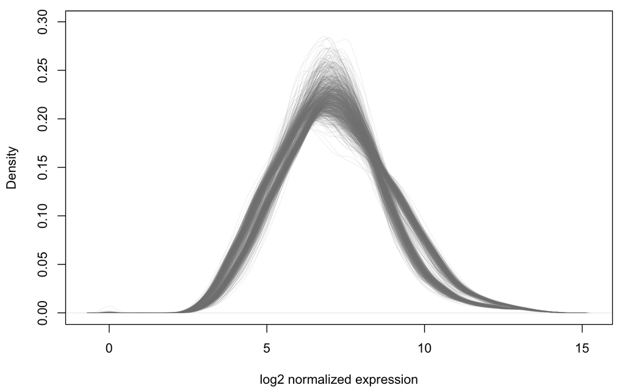

Figure 1. Log2 expression density per sample.

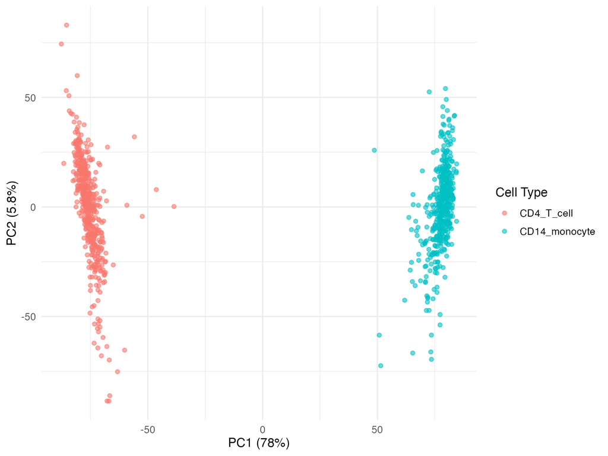

Figure 2. PCA of expression colored by cell type.

The model used for the full analysis was:

```
~ age + (1 | cell_type) + (1 | sex) + (1 | batch) + (1 | individual_id)
```

I chose these model terms to cover biological (`cell_type`), subject-level (`individual_id`), technical (`batch`), and demographic (`age`, `sex`) sources of variation. Cell type represents the CD4+ T cell versus CD14+ monocyte lineage difference. Donor identity accounts for the fact that samples from the same person may be more similar to each other, and that different people can have different baseline expression levels. I included batch even though its median contribution across all modeled probes was low in this analysis (0.00%; mean 0.02%), because excluding batch could allow technical variation to be absorbed by biological variables.

# 3. What I learned about gene expression biology

Among the factors included in the model, cell type explained the largest share of gene expression variation. In the genome-wide summary of modeled probes, `cell_type` explained a median of 48.52% of expression variance, while residual variation explained a median of 43.71%. Donor identity explained a smaller but detectable median fraction of variation, 5.18%. Age, sex, and batch had low median variance (0.04%, 0.00%, and 0.00%, respectively). These median values describe the overall pattern, but they do not mean that age, sex, or batch is unimportant for every individual gene. I return to this point below using the sex component as an example.

The PCA plot in Figure 2 also supported this interpretation: the first principal component separated CD4+ T cells from CD14+ monocytes, consistent with cell type being the largest factor in this analysis.

| Component | Median variance | Mean variance |
| --- | --- | --- |
| cell_type | 48.52% | 47.16% |
| Residuals | 43.71% | 44.46% |
| individual_id | 5.18% | 7.99% |
| age | 0.04% | 0.15% |
| sex | 0.00% | 0.22% |
| batch | 0.00% | 0.02% |

Table 2. Variance component summary.

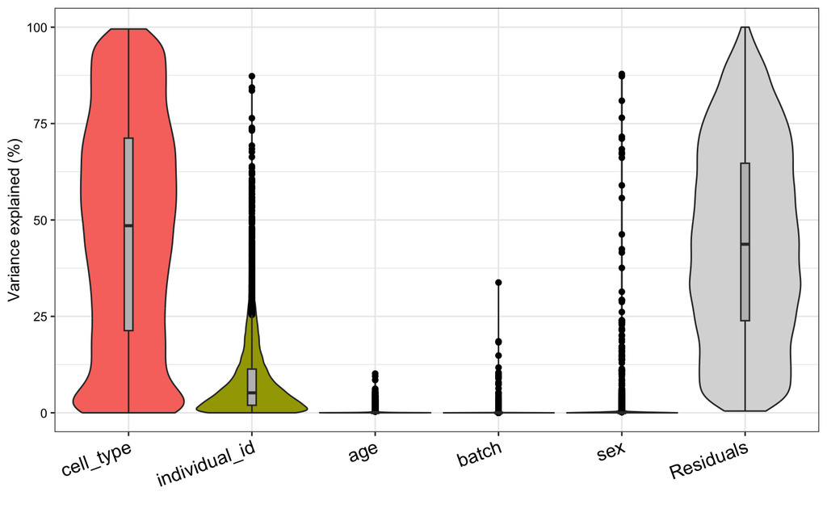

Figure 3. Variance explained by model component across genes.

The large `cell_type` component is biologically expected because CD4+ T cells and CD14+ monocytes are distinct immune cell lineages with different transcriptional programs. Examples among the top cell-type-driven genes included S100A9<sup>[[A]](https://www.proteinatlas.org/ENSG00000163220-S100A9)</sup>, CSF3R<sup>[[B]](https://www.proteinatlas.org/ENSG00000119535-CSF3R)</sup>, TLR8<sup>[[C]](https://www.proteinatlas.org/ENSG00000101916-TLR8)</sup>, MNDA<sup>[[D]](https://www.proteinatlas.org/ENSG00000163563-MNDA)</sup>, LILRB2<sup>[[E]](https://www.proteinatlas.org/ENSG00000131042-LILRB2)</sup>, CD33<sup>[[F]](https://www.proteinatlas.org/ENSG00000105383-CD33)</sup>, FCN1<sup>[[G]](https://www.proteinatlas.org/ENSG00000085265-FCN1)</sup>, and CD68<sup>[[H]](https://www.proteinatlas.org/ENSG00000129226-CD68)</sup>. Several of these genes are consistent with monocyte, granulocyte, macrophage, or broader myeloid biology. I interpret this as a biological plausibility check rather than as a formal gene-set enrichment result. This suggests that the model is detecting real biological differences between CD4+ T cells and CD14+ monocytes, not just technical artifacts.

Donor identity explained less variation overall than cell type, but it still captured detectable person-to-person expression differences. Its median and mean variance explained were 5.18% and 7.99%, respectively, and 2,220 probes had more than 20% of their expression variation attributed to `individual_id`. This suggests that, after accounting for the strong CD4 versus CD14 contrast, a subset of genes remains influenced by donor-to-donor differences.

Sex had a low median contribution across the modeled probes (0.00%; mean 0.22%), but the top sex-driven genes were concentrated among sex-chromosome genes, including ZFY, KDM5D, PRKY, EIF1AY, RPS4Y1, RPS4Y2, UTY, TXLNGY. For these examples, the sex-attributed variance fractions ranged from 87.85% to 67.47% in the order listed. This is reassuring because the model detects sex-linked genes in the sex component, which is exactly the kind of pattern we would expect.

Residual variation remained large (median 43.71%; mean 44.46%). This means the factors included in the model, especially cell type, explain major expression patterns but do not explain all expression differences across samples. The residual component is the remaining variation not assigned to the modeled factors; it may include measurement noise, unmodeled biology, cell-state differences, interaction effects, or probe-level technical variation.

Overall, the main biological result from this healthy-donor ImmVar analysis is that baseline immune-cell expression variation is dominated by cell lineage. CD4+ T cells and CD14+ monocytes show distinct transcriptional programs, while donor identity adds a smaller but measurable layer of person-to-person variation. This is a different type of biological conclusion from a disease case-control analysis: the result is about healthy immune variation and cell identity, not about asthma or another disease phenotype.

# 4. How I would apply this framework

My biological question would be: in asthma or allergic disease, how much airway or immune gene expression heterogeneity is driven by disease phenotype and environmental exposure, compared with cell composition, person-to-person baseline expression differences, and technical batch?

I would apply this framework to a multi-omic asthma or allergic disease cohort, which aligns well with your lab’s focus on clinical phenotypes, environmental exposures, airway biology, and integrating clinical and multi-omic data. For example, in a cohort with gene expression, genotype, methylation, microbiome, cell composition, clinical phenotype, exposure history, sex, age, batch, and repeated samples per individual, variancePartition could estimate how much each data type or clinical factor contributes to expression variation.

This would help distinguish expression differences caused by cell composition from those more directly related to disease status or environmental exposure. It would also help identify individual genes, or groups of genes that vary together, whose variation is driven by a biological factor of interest rather than by technical batch or person-to-person baseline expression differences. With multi-omic data, I could use the same framework to estimate how much airway or immune gene expression variation is explained by methylation patterns, genotype, microbiome features, or environmental exposures.

# 5. Limitations and reproducibility

This analysis is exploratory and depends on public GEO metadata. The data are microarray measurements rather than RNA-seq, and Affymetrix probe-to-gene mapping is not always one-to-one. The percentages from variancePartition show which factors are associated with expression variation, but they do not prove causality. Also, if covariates are correlated with each other, the attribution of variance can be harder to interpret. For this reason, I focused on broad and biologically defensible patterns rather than making strong claims about individual genes.

I also interpreted component-specific top genes cautiously. For example, several Y chromosome genes, including DDX3Y, UTY, and RPS4Y1, appeared among the top batch-associated genes; their batch-attributed variance values were 18.53%, 18.27%, and 11.73%, respectively. Since the metadata showed some imbalance between batch and sex, especially in batch 5 among model-used samples (140 female and 57 male samples; 71.1% female), I interpreted this as partial batch-sex confounding rather than as a biological batch effect on Y-linked genes.

One technical limitation is that certain factors, such as cell_type (CD4+ T cells vs CD14+ monocytes) and sex (Female vs Male), have only two levels. For such binary categorical variables, the estimated variance (random-effect variance) can be less stable because the model has limited information about variation between groups. I followed the variancePartition framework for consistency, but interpreted these components cautiously.

The full analysis is implemented in:

```
variancePartition-exercise.R
```

The full variancePartition result is cached at:

```
results/tables/immvar_variancePartition_full.rds
```

Tables and figures used in this report are generated from the script and stored under `results/tables` and `results/figures`. Key source files include:

- `immvar_qc_summary.csv`
- `immvar_model_sample_exclusion_summary.csv`
- `immvar_variance_component_summary.csv`
- `immvar_top20_genes_by_cell_type.csv`
- `immvar_top20_genes_by_batch.csv`
- `immvar_top20_genes_by_sex.csv`
- `immvar_pca_celltype.png`
- `immvar_variancePartition_full_plot.png`

# References

- [A] Human Protein Atlas. S100A9 protein expression summary. https://www.proteinatlas.org/ENSG00000163220-S100A9
- [B] Human Protein Atlas. CSF3R protein expression summary. https://www.proteinatlas.org/ENSG00000119535-CSF3R
- [C] Human Protein Atlas. TLR8 protein expression summary. https://www.proteinatlas.org/ENSG00000101916-TLR8
- [D] Human Protein Atlas. MNDA protein expression summary. https://www.proteinatlas.org/ENSG00000163563-MNDA
- [E] Human Protein Atlas. LILRB2 protein expression summary. https://www.proteinatlas.org/ENSG00000131042-LILRB2
- [F] Human Protein Atlas. CD33 protein expression summary. https://www.proteinatlas.org/ENSG00000105383-CD33
- [G] Human Protein Atlas. FCN1 protein expression summary. https://www.proteinatlas.org/ENSG00000085265-FCN1
- [H] Human Protein Atlas. CD68 protein expression summary. https://www.proteinatlas.org/ENSG00000129226-CD68